2022-07-20

# New bootstrap method

Here, we:

1. Fit each of the simulated curves
2. For 1 in 1:B, sample from each group with replacement
3. From each sampled group, draw new parameters from fitted distribution
4. repeat

We start with 20 subjects in each group, the two groups being group A and B

Before we begin, here are the bootstrap means from bdots proper

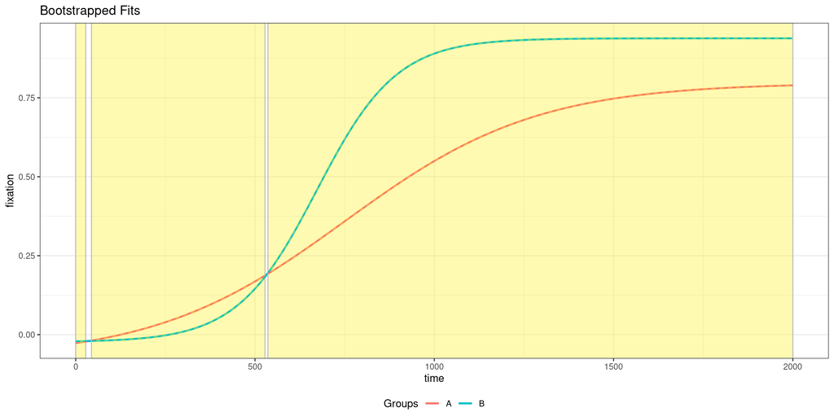

## Group A

First, we compare the original curve against all B = 1000 bootstraps from the new method

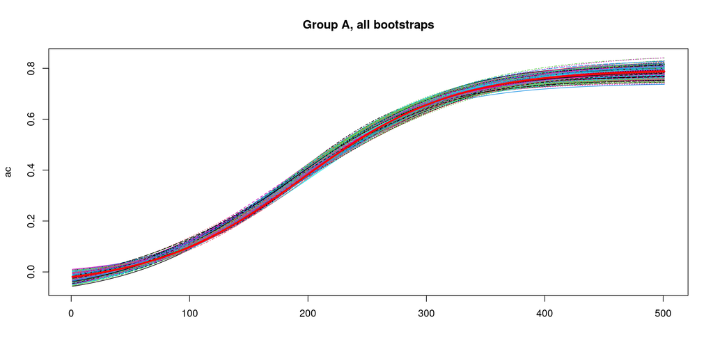

We also plot the 95% CI using quantiles and standard deviation, showing the bootstrapped mean as well as the original curve

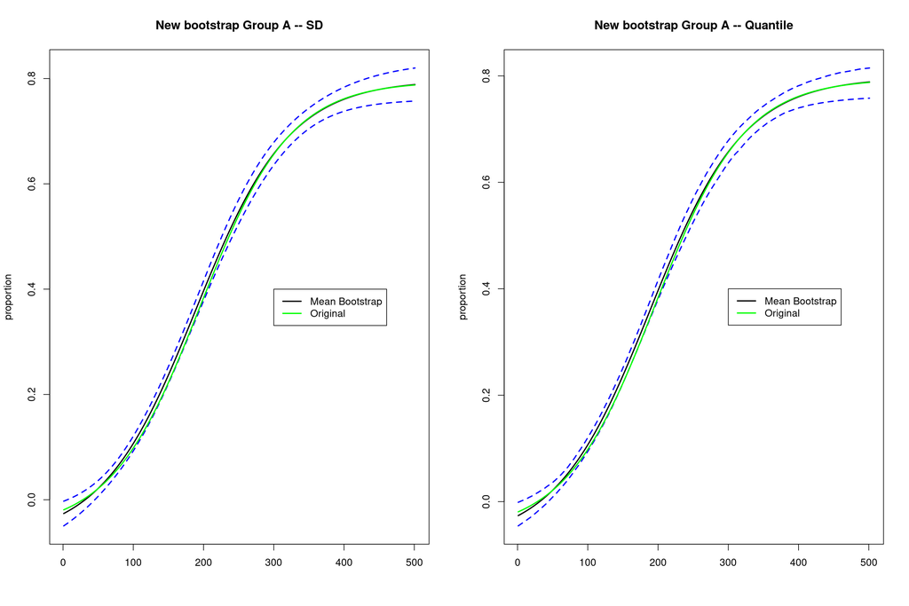

We then compare SD and quantile between bdots and new method. I don’t include the original curve, though its obviously situated between the two bands. Note that for the quantile, they are nearly on top of each other for original bdots

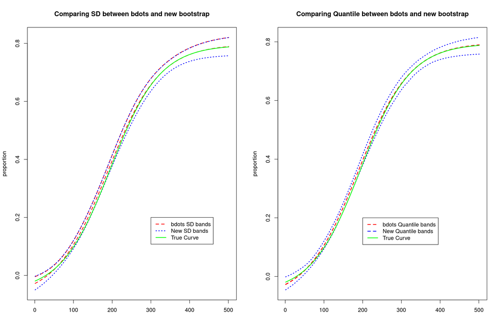

For completeness, we show the mean bootstrapped curves compared with the original. As perhaps expected, the mean bootstraps are both nearly identical

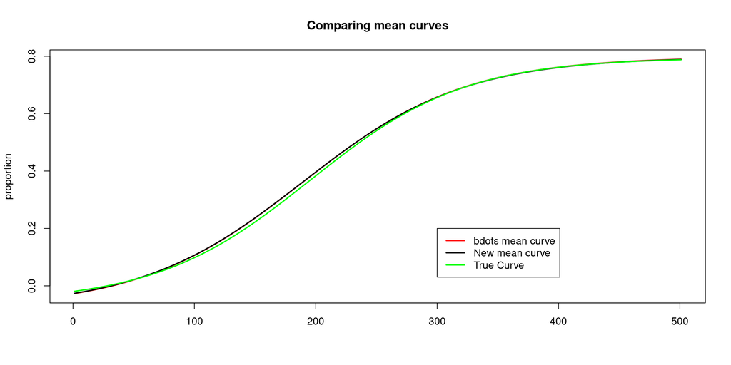

We’ll repeat the same thing with group B

## Group B

First, collection of bootstraps from new method

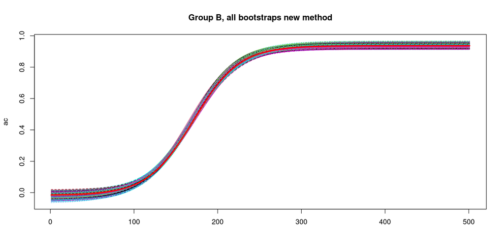

Then SD and quantile of the new method

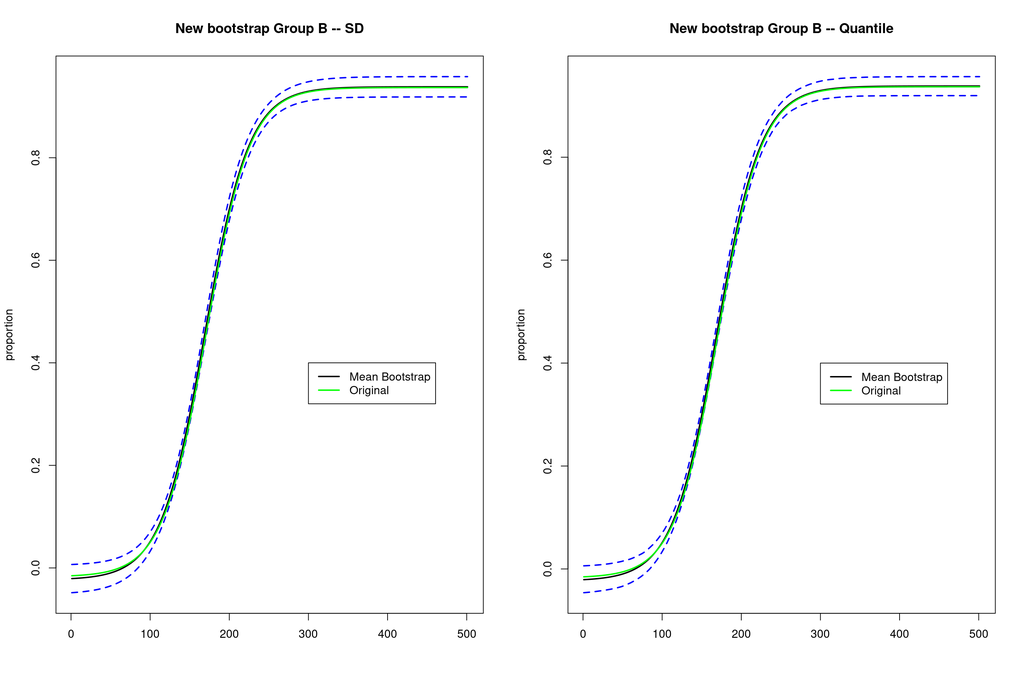

Finally, a comparison between bdots and new

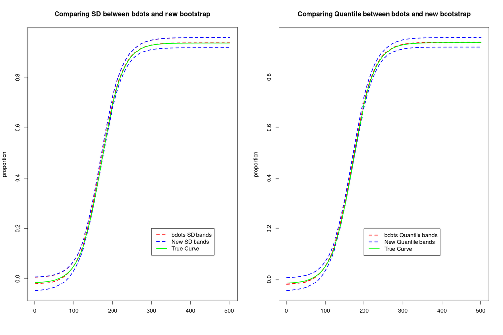

And mean curves to round it off

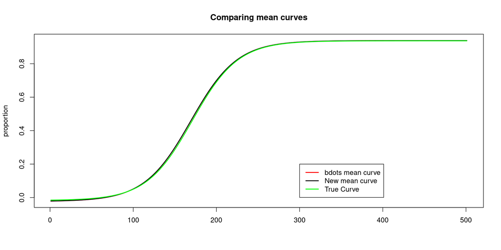

# Round 2

We are going to do the same thing again, but with 100 subjects in each group (hoping to better recover true mean curve), still 1000 bootstraps. We will limit plots to simply looking at the derived quantile and sd bands. No need to look at bdots as we are interested in performance of new method

## Group A

Quantile and SD bands

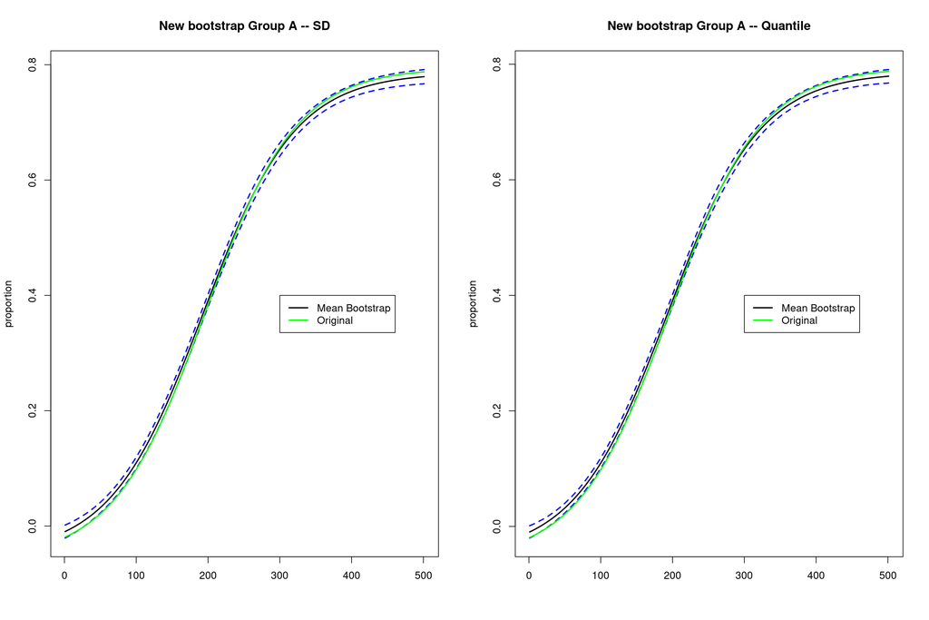

## Group B

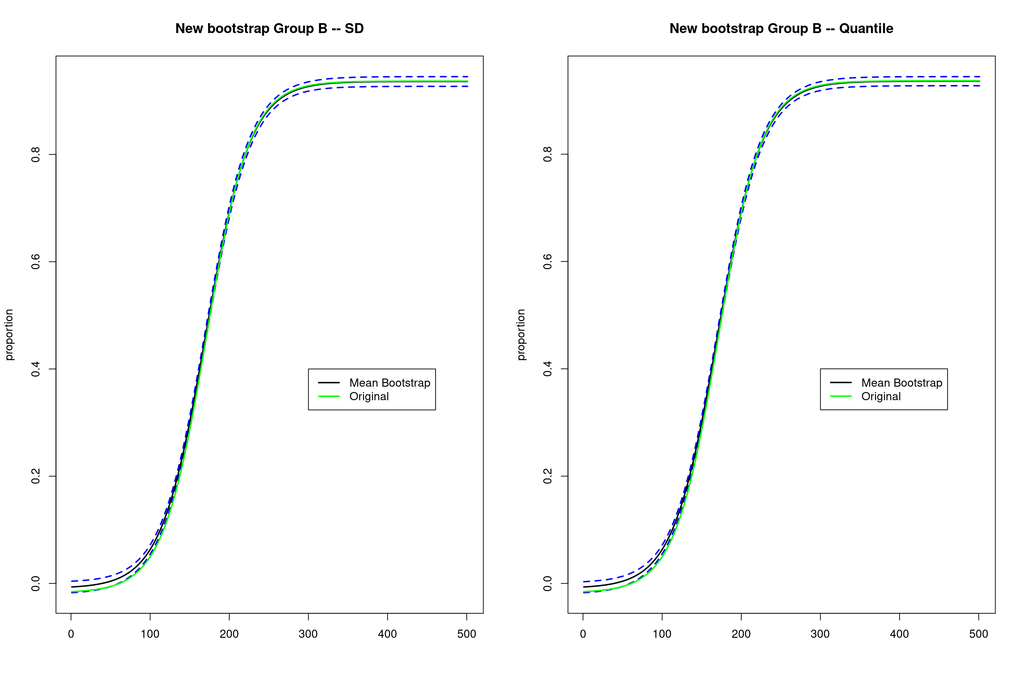

# Curious about convergence

Nevermind the bootstrapped bits. If I have enough subjects, will my mean fitted curve asymptotically approach the generating curve? Let’s try with N = 1000 subjects

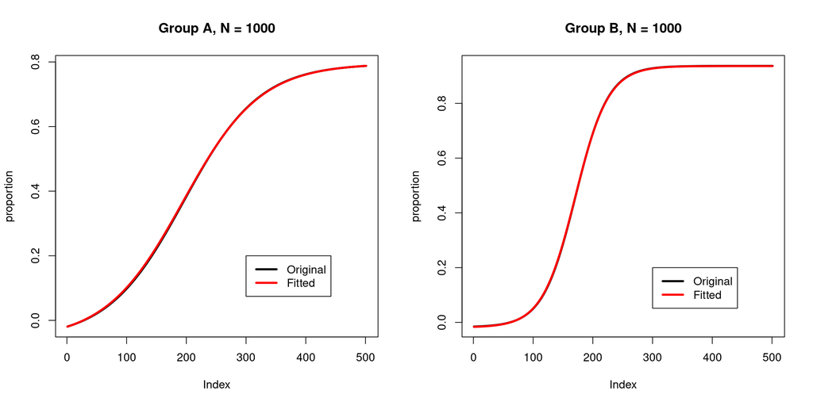

# Takeaways

1. It seems that new method has better coverage than old (compute coverage as percentage of domain?)
2. Still having issues with lower bound of curve in index 100-300 range (same as before)
3. Increasing subjects seems to narrow the bands but not necessarily improve convergence to true curve. Peculiar

# Bonus

I accidentally plotted the tranpose of a matrix and it ended up being pretty neat

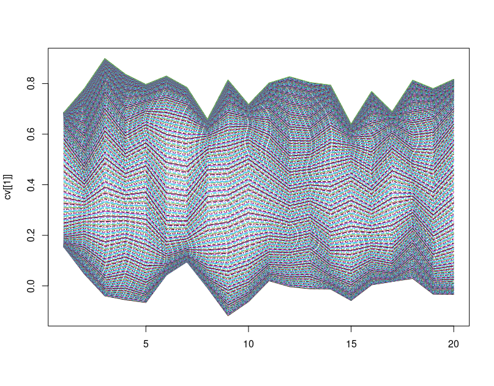

neat